# Problem Set 2

Statistics and Econometrics

Due: 10am, 9 Nov 2023

## General Guideline

What we are looking for in the assignments is a demonstration that you can understand the econometrics and statistics questions and can solve them with R or conceptually. That means effective programming to get correct results is needed, but at the same time, clear explanations of economics/business concepts in well presented reports are equally important when assessing your work. In particular, you will be marked for successful (correct) programming (not the style of coding), good understanding of related concepts, and clear interpretations and explanations of results.

Please submit a pdf or html file converted from R markdown/notebook after you program in R.

```r
library(ggplot2)
library(stargazer)
library(car)
```

## Question 1 (35 marks)

Use bwght.RData for this exercise. The data set contains data on births to women in the United States. A problem of interest to health officials (and others) is to determine the effects of smoking during pregnancy on infant health. One measure of infant health is birth weight (variable $bwght$); a birth weight that is too low can put an infant at risk for contracting various illnesses.

1. Estimate the simple regression model
   $$bwght=\beta_0+\beta_1 cigs+u,$$
   and report your results. To predict a birth weight of $125$ ounces, what would $cigs$ have to be? Comment.

**Answer 1.1**

```r
# view the data
load('bwght.RData')
# make sure no null values in the columns used
sum(is.na(data$bwght))
```

```
## [1] 0
```

```r
sum(is.na(data$cigs))
```

```
## [1] 0
```

```r
sum(is.na(data$faminc))
```

```
## [1] 0
```

```r
desc
```

| variable | label |
| --- | --- |
| faminc | 1988 family income, $1000s |
| cigtax | cig. tax in home state, 1988 |
| cigprice | cig. price in home state, 1988 |
| bwght | birth weight, ounces |
| fatheduc | father's yrs of educ |
| motheduc | mother's yrs of educ |
| parity | birth order of child |
| male | =1 if male child |
| white | =1 if white |
| cigs | cigs smked per day while preg |

[output cut: 4 more lines]

```r
# create the model
m1 = lm(data = data, bwght~cigs)
stargazer(m1, header = F, type = 'html', title = "Question 1.1")
```

**Question 1.1**

|  | *Dependent variable:* |
| --- | --- |
|  | bwght |
| cigs | -0.514*** |
|  | (0.090) |
| Constant | 119.772*** |
|  | (0.572) |
| Observations | 1,388 |
| R<sup>2</sup> | 0.023 |
| Adjusted R<sup>2</sup> | 0.022 |
| Residual Std. Error | 20.129 (df = 1386) |
| F Statistic | 32.235*** (df = 1; 1386) |
| *Note:* | p<0.1; p<0.05; p<0.01 |

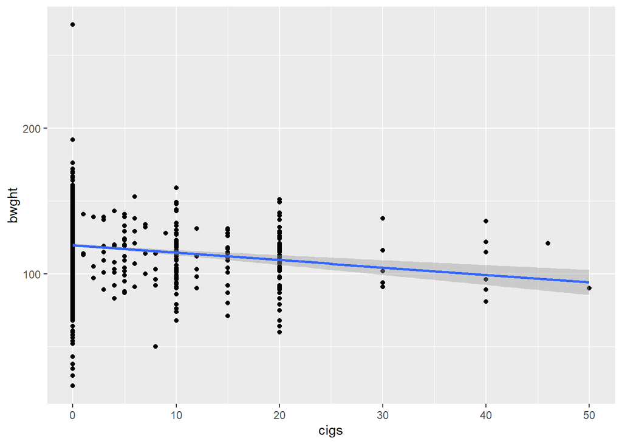

```r
ggplot(data = data, aes(x = cigs, y = bwght)) + geom_point() + geom_smooth(method = 'lm', formula = y ~ x)
```

Based on the simple linear regression model, one more cigarette per day during pregnancy is predicted to decrease the infant birth weight by 0.514 ounces.

The model indicates that
$$\widehat{bwght}
= \widehat{\beta_0}+\widehat{\beta_1}cigs$$

$\widehat{\beta_0}$ is estimated to be 119.772; and $\widehat{\beta_1}$ is estimated to be -0.514. cigs is statistically significant at 1% significance level. Therefore, we can calculate cigs based on 125 = 119.772 -0.514*cigs

```r
# cigs = (125 - 119.77190)/-0.51377
(125 - 119.772)/-0.514
```

```
## [1] -10.17121
```

Based on the model, around -10 cigarettes per day during pregnancy is predicted to have an infant weighing 125 ounces, which is an unrealistic prediction since cigarette consumption can never be negative.The result is because firstly, 125 is larger than the intercept (=119.7719) of the regression line, so the predicted x (cigs) goes to the negative. In reality, there is a feasible range of cigarette consumption per day, but the regression line doesn’t take the range into account.Secondly, we can see from the plot that there are many different bwght data points when cigs = 0, but the regression line simplifies them to only one bwght. Most data points concentrate at cigs < 20, and there are only a few data points for cigs > 30 with large intervals. With very small R^2 (=0.023), we can also tell that the regression line does not describe the relationship between cigs and bwght well.

2. What is the proportion of women in the sample who do not smoke while pregnant? Does this reconcile your finding from part 1?

**Answer 1.2**

```r
nrow(data[data$cigs == 0,])/nrow(data)
```

```
## [1] 0.8472622
```

Yes. Around 84.72622% of women in the sample don’t smoke while pregnant, which helps to explain why we derive an unrealistic prediction in the previous question. Most data points concentrate at cigs = 0, and the variation of bwght is large.

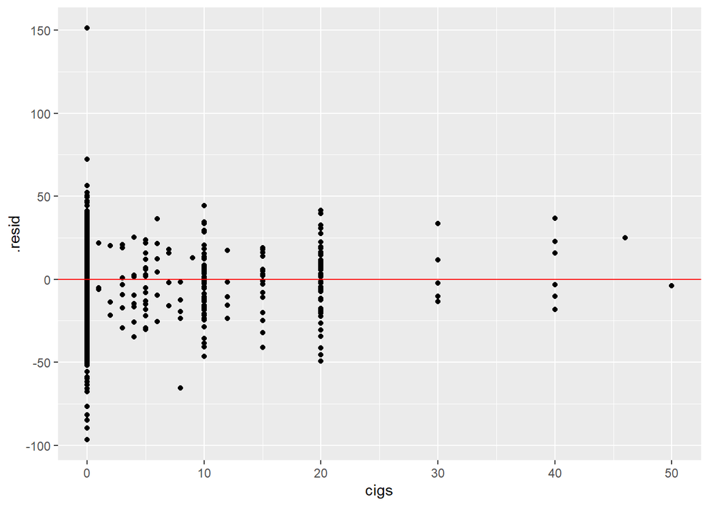

```r
ggplot(m1, aes(cigs, .resid)) + geom_point() +geom_hline(yintercept=0, col="red")
```

From the residual plot we can tell that the variance of residuals differs for different cigs and shows certain pattern. This is an indication of heteroscedasticity, which means the assumption of constant variance of residuals in a regression model is violated. When there’s heteroscedasticity, OLS estimators are not good estimators.

3. Since factors other than cigarette smoking (variable $cigs$) that affect birth weight are likely to be correlated with smoking, we should take those factors into account. For example, higher income (variable $faminc$) generally results in access to better prenatal care, as well as better nutrition for the mother. An equation that recognizes this is:
   $$bwght =
   \beta_0+\beta_1 cigs + \beta_2 faminc +u.$$
   What is the most likely sign for $\beta_2$?

**Answer 1.3** The sign of $\beta_2$ is likely to be positive, according to the description that higher family income generally results in access to better prenatal care, better nutrition for the mother, and heavier weight of the infant. $\beta_2$ is the coefficient of faminc, representing the change of bwght when faminc increases by 1 unit ($1000s). It is expected to see faminc and bwght co-move in the same direction, so $\beta_2$ should be positive.

4. Do you think $cigs$ and $faminc$ are likely to be correlated? Explain why the correlation might be positive or negative.

**Answer 1.4** Yes. The correlation is likely to be negative, since high-income individuals (and therefore having high family income in general) tend to care more about or have access to health information. That is, they are more likely to know smoking cigarettes while pregnant is bad and prevent such practice. In addition, low-income individuals tend not to work laborious jobs such as construction workers, mining workers, hairdressers, which are the occupational groups with prevalent smoking habits. Therefore, it’s likely to discover a negative correlation between cigs and faminc.

```r
cor(data$cigs, data$faminc, use = "complete.obs")
```

```
## [1] -0.1730449
```

We examine the correlation between cigs and faminc from the sample, and it is negative.

5. Now, estimate the model in part 3. Compare your result with the model estimated in part 1, focusing on whether adding $faminc$ substantially changes the estimated effect of $cigs$ on $bwght$.

**Answer 1.5**

```r
# create a MLR model
m2 = lm(data = data, bwght~cigs+faminc)
stargazer(m1, m2, type = 'html', align = TRUE)
```

|  | *Dependent variable:* |  |
| --- | --- | --- |
|  | bwght |  |
|  | (1) | (2) |
| cigs | -0.514*** | -0.463*** |
|  | (0.090) | (0.092) |
| faminc |  | 0.093*** |
|  |  | (0.029) |
| Constant | 119.772*** | 116.974*** |
|  | (0.572) | (1.049) |
| Observations | 1,388 | 1,388 |
| R<sup>2</sup> | 0.023 | 0.030 |
| Adjusted R<sup>2</sup> | 0.022 | 0.028 |
| Residual Std. Error | 20.129 (df = 1386) | 20.063 (df = 1385) |
| F Statistic | 32.235*** (df = 1; 1386) | 21.274*** (df = 2; 1385) |
| *Note:* | p<0.1; p<0.05; p<0.01 |  |

The coefficient of cigs changes from -0.514 to -0.463 when adding faminc to the model. In both models, cigs is statistically significant at 1% level. faminc is statistically significant at 1% significance level in m2. The effect of cigs on bwght is overestimated in m1 (SLR) since relevant varaiable faminc is omitted in m1 and there is negative omitted variable bias. If we regress faminc on cigs, the coefficient of cigs is -0.5429278. The negative bias is composed of $\widehat{\beta_2} * -0.5429278$, which is around -0.05049229. $\widehat{\beta_1}$ in m1 includes the negative bias while $\widehat{\beta_1}$ in m2 does not. If we add the negative bias to $\widehat{\beta_1}$ in m2, we can get $\widehat{\beta_1}$ in m1 approximately.

```r
# regress faminc on cigs
m3 = lm(data = data, faminc~cigs)
# the effect of cigs on faminc
m3$coefficient
```

```
## (Intercept)        cigs
##  30.1598428  -0.5429278
```

```r
# bias
-0.5429278*0.093
```

```
## [1] -0.05049229
```

```r
# plug back
-0.463 + -0.5429278*0.093
```

```
## [1] -0.5134923
```

## Question 2 (40 marks)

The following model can be used to study whether campaign expenditures affect election outcomes:
$$voteA = \beta_0 + \beta_1\log(expendA) +
\beta_2\log(expendB) + \beta_3prtystrA + u,$$
where $voteA$ is the percentage of the vote received by Candidate A, $expendA$ and $expendB$ are campaign expenditures by Candidate A and B, and $prtystrA$ is a measure of party strength for Candidate A (the percentage of the most recent presidential vote that went to A’s party).

1. What is the interpretation of $\beta_1$?

**Answer 2.1** Given that voteA refers to percent vote for A, $\beta_1$ indicates the % change of vote received by candidate A When expenditures by candidate A increase by 1%, holding other things fixed.

2. Estimate the given model using vote1.RData and report the results. Do A’s expenditures affect the outcome? What about B’s expenditures? (please show clearly the test statistic and the critical value used in your testing).

**Answer 2.2**

```r
# load the data
load('vote1.RData')
# no missing values
sum(is.na(data))
```

```
## [1] 0
```

```r
desc
```

| variable | label |
| --- | --- |
| state | state postal code |
| district | congressional district |
| democA | =1 if A is democrat |
| voteA | percent vote for A |
| expendA | camp. expends. by A, $1000s |
| expendB | camp. expends. by B, $1000s |
| prtystrA | % vote for president |
| lexpendA | log(expendA) |
| lexpendB | log(expendB) |
| shareA | 100*(expendA/(expendA+expendB)) |

```r
# regress voteA on log(expendA), log(expendB), and prtystrA
# the result is the same if we do lm(data = data, voteA~log(expendA) + log(expendB)+prtystrA)
m4 = lm(data = data, voteA~lexpendA+lexpendB+prtystrA)
stargazer(m4, type = 'html')
```

|  | *Dependent variable:* |
| --- | --- |
|  | voteA |
| lexpendA | 6.083*** |
|  | (0.382) |
| lexpendB | -6.615*** |
|  | (0.379) |
| prtystrA | 0.152** |
|  | (0.062) |
| Constant | 45.079*** |
|  | (3.926) |
| Observations | 173 |
| R<sup>2</sup> | 0.793 |
| Adjusted R<sup>2</sup> | 0.789 |
| Residual Std. Error | 7.712 (df = 169) |
| F Statistic | 215.227*** (df = 3; 169) |
| *Note:* | p<0.1; p<0.05; p<0.01 |

The coefficient of lexpendA is 6.083; the coefficient of lexpendB is -6.615; the coefficient of prtystrA is 0.152. The effect of prtystrA (% vote for president) on voteA is statistically significant at 5% level.

```r
# we can approximate the sample distribution of estimated beta1 and beta2 to normal distribution
# since sample size is large
nrow(data)
```

```
## [1] 173
```

```r
# critical values at 1 % significance level
qnorm(0.995) # normal distribution
```

```
## [1] 2.575829
```

```r
qt(0.995,df = 173-3-1) # t distribution
```

```
## [1] 2.605233
```

```r
# H0: beta_1 = 0
# t score of beta1
(6.083-0)/0.382
```

```
## [1] 15.92408
```

```r
# H0: beta_21 = 0
# t score of beta2
(-6.615 -0)/0.379
```

```
## [1] -17.45383
```

$|t_\widehat{\beta_1}|$ and $|t_\widehat{\beta_2}|$ are larger than the critical value, regardless of using critical value 2.575829 or 2.605233.

$|15.92408| > 2.575829$ or $2.605233$, $|-17.45383|> 2.575829$ or $2.605233$

This means we can reject the null hypothesis that $\beta_1$ and $\beta_2$ are zero (reject the saying that lexpendA and lexpendB have no effect on voteA). lexpendA and lexpendB are statistically significant at 1% level.

3. In terms of the parameters, state the null hypothesis that a 1% increase in A’s expenditures is offset by a 1% increase in B’s expenditures.

**Answer 2.3**

$H0: \beta_1 + \beta_2 = 0$

That is,

$H0: \beta_1 = -\beta_2$

4. Test the hypothesis in part 3. What is your conclusion? (hint: you can use linearHypothesis() function to test hypotheses that involve more than one parameters.)

**Answer 2.4**

```r
linearHypothesis(m4, "lexpendA = -lexpendB")
```

|  | Res.Df | RSS | Df | Sum of Sq | F | Pr(>F) |
| --- | --- | --- | --- | --- | --- | --- |
| 1 | 170 | 10111.40 | NA | NA | NA | NA |
| 2 | 169 | 10052.14 | 1 | 59.26056 | 0.9963088 | 0.3196323 |

Given high p-value of F statistics (0.3196323) larger than significance level at 10%, we fail to reject the null hypothesis even at 10% significance level. We cannot reject that 1% increase in candidate A’s expenditures is offset by 1% increase in candidate B’s expenditures.

5. Plot residuals against fitted values for the model estimated in part 2. Comment.

**Answer 2.5**

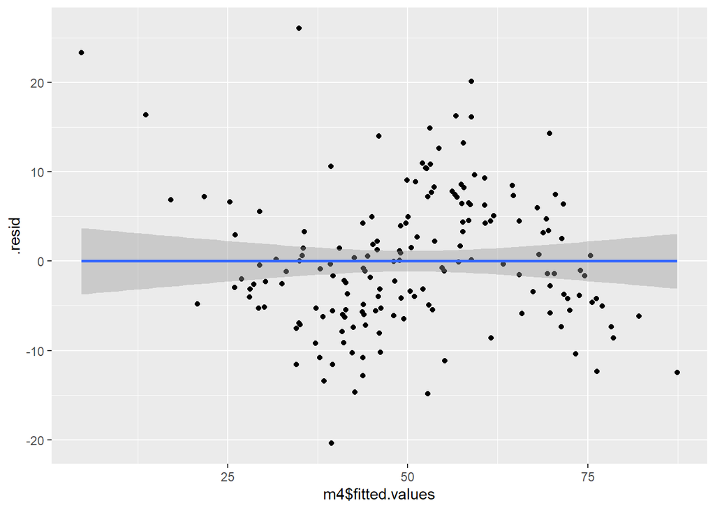

```r
ggplot(m4, aes(y = .resid, x = m4$fitted.values)) + geom_point() + stat_smooth(method = "lm")
```

The residuals are mostly negative when fitted values are in a range of 25 to 50 and over 75; the residuals are mostly positive when fitted values are in a range of 50 to 75 and below 25. There is a certain pattern in the plot, suggesting non-linearity. The pattern indicates dependency between the residuals and the fitted values, so a non-linear model may fit the data better.

## Question 3 (25 marks)

In class, we discussed the concepts of individual significance and joint significance. Consider the model
$$y=\beta_0+\beta_1 x_1 +\cdots + \beta_k x_k +
u.$$
Someone asserts that if $x_j$ is individually significant in the model, then it must be jointly significant when it is tested along with some other variables. Do you agree? Explain.

**Answer 3** No, the statement is wrong. Sometimes, some independent variables are tested to be significant individually, but they are not jointly significant when all included in the model. This is because these independent variables are correlated with each other, so we cannot separate their individual effects on dependent variable. If in a multiple regression model, there is strong correlation between independent variables, the phenomenon is known as multicollinearity. A |correlation| > 0.7 is considered strong correlation in general practice.

We can use a F test to test the joint significance of independent variables. Firstly, we set up a restricted model containing q restrictions, e.g. $\beta_1 =\beta_2 = 0$, and a unrestricted model containing all the independent variables. The restricted model is linked to the null hypothesis e.g. $\beta_1 =\beta_2 = 0$ and have fewer independent variables. We then calculate the F statistic by the formula:
$$F = [(R_{ur}^2 - R_{r}^2)/q]
/[(1-R_{ur}^2)/(n-k-1)]$$
The n-k-1 refers to the degree of freedom. If F statistic is larger than the critical value corresponding to the significance level, null hypothesis is rejected. That is, $x_1$ and $x_2$ are jointly significant.

Multicollinearity could lead to problems. For instance, firstly, coefficient estimates could become unstable and sensitive to small changes of data. Secondly, coefficient estimates do not represent true marginal effects, since there are redundant independent variables so the regression model cannot correctly separate their effects. Thirdly, coefficient standard errors could be large, making it difficult to reject null hypothesis $\beta_k = 0$ even when the effect of $x_k$ is strong. Lastly, large coefficient standard errors could also lead to wider confidence intervals and less accurate, less meaningful result of hypothesis testing.

By using variance inflation factors (VIF), we are able to detect multicollinearity. VIF for $x_j$ is computed by $1/(1-R_j^2)$. If $x_j$ is strongly correlated to other independent variables, $R_j^2$ will be close to 1 and $1- R_j^2$ will be close to 0, so $VIF_j$ will be large. In general, VIF larger than 10 indicates multicollinearity problem.

When multicollinearity happens, it is recommended to drop some redundant variables among those who are highly correlated.